# Taller 5: Datos raster con {terra}

Uso Avanzado de Sistemas de Información Geográfica

Autor/a

Afiliación

Dr. Francisco Zambrano

Escuela de Ingeniería en Medio Ambiente, Universidad Mayor

Fecha de publicación

23 de septiembre de 2024

# 1 Descripción

## 1.1 Descripción datos

- dem_chile.tif : datos de elevación para chile
- temp_chile.tif: datos de temperatura promedio mensual para chile (1990-2020)
- prec_chile.tif: datos de precipitación acumulada mensual para chile (1990-2020)

Descargar desde [acá](https://drive.google.com/drive/folders/1gXapUcoHkQxNBm0-WDBpmZxmMGSnbRob?usp=sharing)

# 2 Objetivo del taller

Familiarizarce con `{terra}` para crear datos raster, asignarles SRC, transformar los SRC, leer y guardar archivos rasters desde/hacia el disco, y explorar su estructura.

# 3 Instalar y cargar {terra}

Hasta el momento en el curso hemos trabajado con los paquetes que vienen inculidos en R base (stats, graphics, grDevices, utils, datasets, methods y base). Ahora empezaremos a trabajar con paquetes adicionales que no vienen instalados por defecto en `R`, por lo que deberá instalarlos y cargarlos en R. En este taller trabajaremos con `{terra}` para poder manejar datos espaciales rasters.

Para instala y cargar `{terra}` debe realizar lo siguiente:

**Código**

```r
# instala {terra}
install.packages('terra')

# cargar {terra} en el entorno de R para poder utilizar
# las funciones adicionales para manejo de datos vectoriales que contiene

library(terra)
```

## 3.1 Data

Se proporcionan capas rasters con los que deberá trabajar en el taller, estas corresponden a datos de elevación, temperatura y precipitacipón.

# 4 ¿Qué debe entregar?

Deberá utilizar RStudio para crear un script, en donde resolverá cada uno de los ejercicios. Debe utilizar los comentarios (`#`) para hacer una descripción del ejercicio e incorporar cualquier información que ayude a entender lo realizado. A modo de ejemplo:

**Código**

```r
# Ejercicio 1:
# comentario explicando lo que se hace
{
 Aca va el script que resuelve el ejericio 1

}
```

Debe guardar el script con el nombre `taller5.R`. Los archivos los debe subir en el campus virtual en la sección `Actividades -> Evaluaciones -> Talleres -> Taller5`

# 5 Fecha de entrega

Lunes 30 de septiembre hasta las 08:30am

# 6 Ejercicios

1.- Cree un objeto llamdo `r` de tipo `spatRaster` que tenga una extensión entre las latitudes 33°30’ y 32°30’ Sur; y entre las longituded 70°40’ y 69°40 Oeste. Indique:

- las unidades
- la resolución espacial
- cantidad de filas y columnas
- el sistema de referencia de coordenadas

**Código**

```r
library(terra)
```

**Código**

```r
lat <- c(-33-30/60, -32-30/60)
lon <- c(-70 - 40/60,-69-40/60)

r <- rast(xmin = lon[1],xmax=lon[2],
          ymin=lat[1],ymax = lat[2])

# unidades en grados

#resolución
res(r)
```

```
[1] 0.002777778 0.005555556
```

**Código**

```r
#- cantidad de filas y columnas
dim(r)
```

```
[1] 180 360   1
```

**Código**

```r
#- el sistema de referencia de coordenadas

crs(r)
```

```
[1] "GEOGCRS[\"WGS 84\",\n    DATUM[\"World Geodetic System 1984\",\n        ELLIPSOID[\"WGS 84\",6378137,298.257223563,\n            LENGTHUNIT[\"metre\",1]],\n        ID[\"EPSG\",6326]],\n    PRIMEM[\"Greenwich\",0,\n        ANGLEUNIT[\"degree\",0.0174532925199433],\n        ID[\"EPSG\",8901]],\n …
```

2.- Cree un objeto llamdo `r` de tipo `spatRaster` que tenga una extensión entre las latitudes 33°30’ y 32°30’ Sur; y entre las longituded 70°40’ y 69°40 Oeste. El raster debe tener 10 filas y 5 columnas; y debe tener como valores en las celdas los números del 1 al 50.

**Código**

```r
lat <- c(-33-30/60,-32-30/60)
lon <- c(-70-40/60,-69-40/60)

r <- rast(xmin = lon[1],xmax = lon[2],
          ymin = lat[1],ymax = lat[2],
          nrow = 10,ncol = 5, vals = 1:50)
```

3.- Cree un raster que tenga una extensión entre 350.000m y 450.000m Este y 6.400.000m y 6.500.000m Norte (UTM EPSG:32719). Que tenga 10 filas y 10 columnas. Agregue los valores a cada celda del 100 al 1. Haga un plot del raster y muestre los valores en la celdas.

**Código**

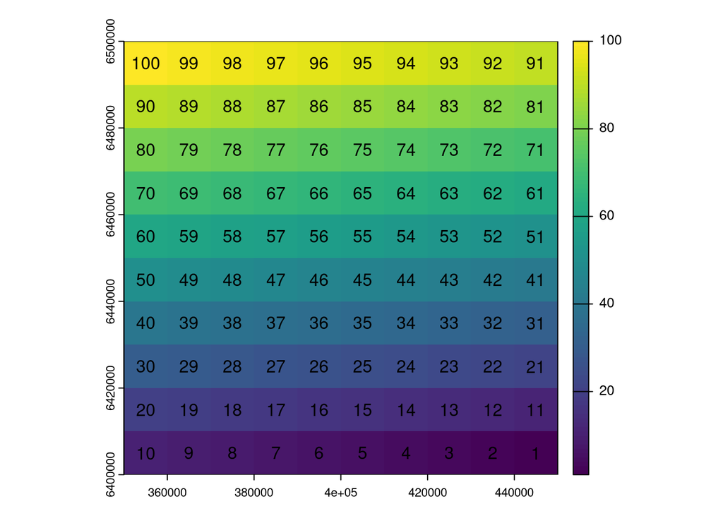

```r
r <- rast(xmin = 350000,xmax = 450000,
          ymin=6400000,ymax = 6500000,
          nrow = 10, ncol = 10,vals = 100:1)
plot(r)
text(r)
```

4.- Cree un raster de tres capas, que tenga 3 filas y 3 columnas. Los pixeles de la primera capa debe tener los valores 1 a 9, de la segunda de 10 a 18 y la tercera de 19 a 27.

**Código**

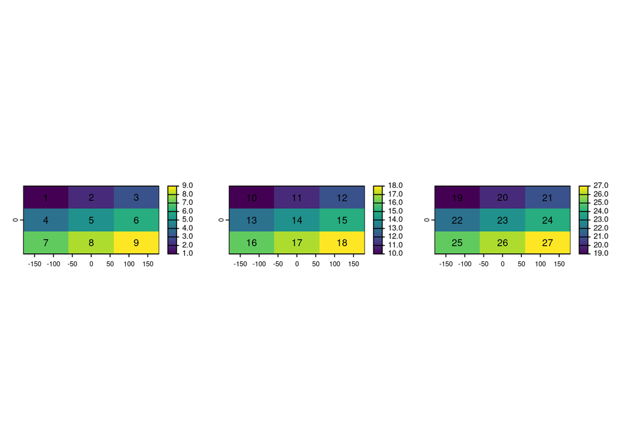

```r
#forma 1
r <- rast(nrow=3,ncol=3)
r3 <- c(r,r,r)
values(r3) <- 1:27
par(mfrow=(c(1,3)))

#forma 2
a <- array(data=1:27,dim =c(3,3,3))
r3_v2 <-rast(a)

plot(r3[[1]])
text(r3[[1]])
plot(r3[[2]])
text(r3[[2]])
plot(r3[[3]])
text(r3[[3]])
```

5.- Haga la suma de las tres capas de él raster de la pregunta anterior. Guarde el resultado en un nuevo raster. Cree un plot del raster y muestre los valores en cada celda.

**Código**

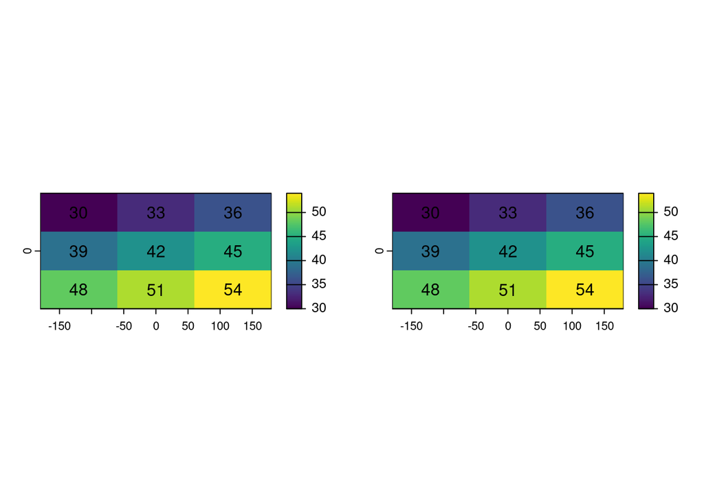

```r
#forma 1
sumr3 <- sum(r3)

#forma 2
sumr3_v2 <- app(r3,sum)

par(mfrow=c(1,2))
plot(sumr3);text(sumr3)
plot(sumr3_v2);text(sumr3_v2)
```

6.-Para el raster de la pregunta anterior aplique a cada celda la raiz cuadrada (`sqrt`) y guarde el raster en un objeto nuevo. Guarde el objeto raster en disco con el nombre `r_sqrt.tif`.

**Código**

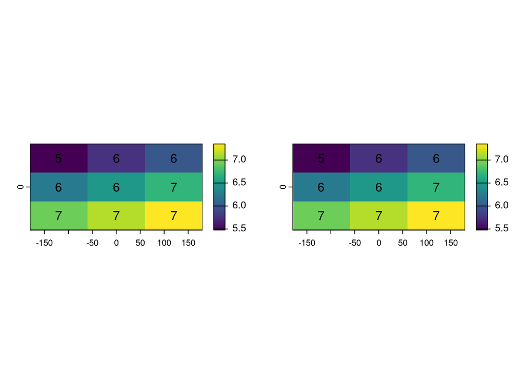

```r
#forma 1
sqrtr3 <- sqrt(sumr3)

#forma 2
sqrtr3_v2 <- app(sumr3,sqrt)

par(mfrow=c(1,2))
plot(sqrtr3);text(sqrtr3)
plot(sqrtr3_v2);text(sqrtr3_v2)
```

7.- De los archivos raster que descargó en la sección data. Indique para cada uno de los archivos raster lo siguiente:

- Sistema de Referencia de Coordenadas
- Número de filas y columnas
- Resolución espacial
- Número de capas (layers)
- Haga un plot de cada raster.

**Código**

```r
dem <- rast('../data/capas_raster/dem_chile.tif')
prec <- rast('../data/capas_raster/prec_chile.tif')
temp <- rast('../data/capas_raster/temp_chile.tif')
```

**Código**

```r
#- Sistema de Referencia de Coordenadas

crs(dem,describe = TRUE)
```

```
    name authority code area         extent
1 WGS 84      EPSG 4326 <NA> NA, NA, NA, NA
```

**Código**

```r
crs(prec,describe = TRUE)
```

```
    name authority code area         extent
1 WGS 84      EPSG 4326 <NA> NA, NA, NA, NA
```

**Código**

```r
crs(temp,describe = TRUE)
```

```
    name authority code area         extent
1 WGS 84      EPSG 4326 <NA> NA, NA, NA, NA
```

**Código**

```r
#- Número de filas y columnas

dim(dem)
```

```
[1] 4656 1884    1
```

**Código**

```r
dim(prec)
```

```
[1] 4620 5220   12
```

**Código**

```r
dim(temp)
```

```
[1] 4620 5220   12
```

**Código**

```r
#- Resolución espacial
res(dem)
```

```
[1] 0.008333333 0.008333333
```

**Código**

```r
res(prec)
```

```
[1] 0.008333333 0.008333333
```

**Código**

```r
res(temp)
```

```
[1] 0.008333333 0.008333333
```

**Código**

```r
#- Número de capas (layers)
nlyr(dem)
```

```
[1] 1
```

**Código**

```r
nlyr(prec)
```

```
[1] 12
```

**Código**

```r
nlyr(temp)
```

```
[1] 12
```

**Código**

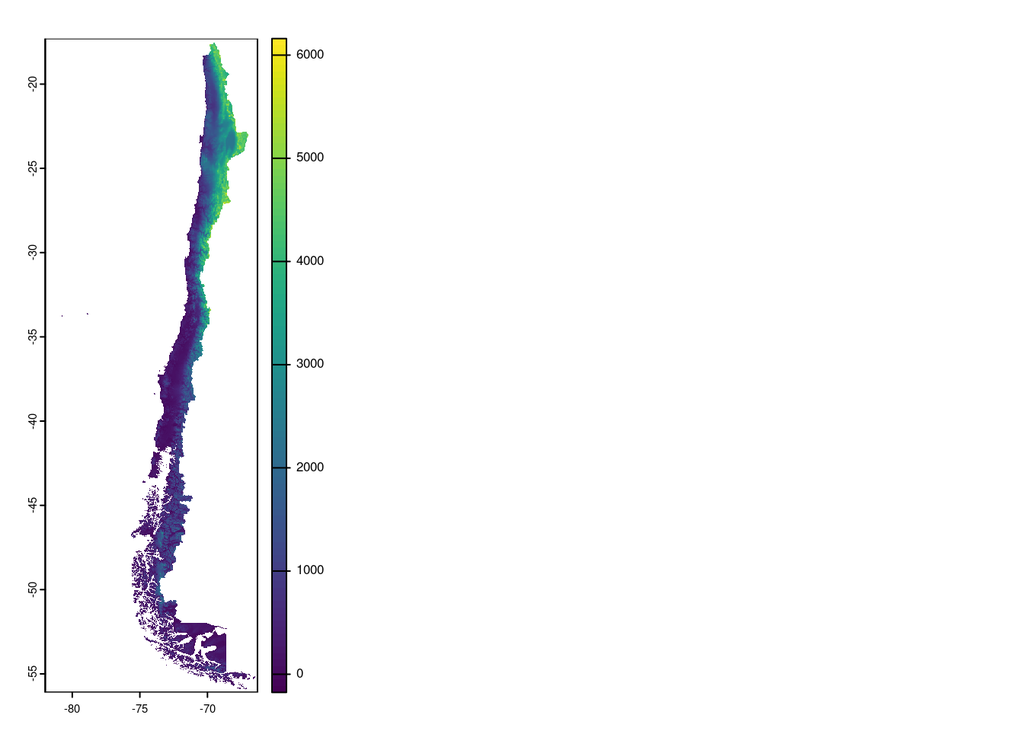

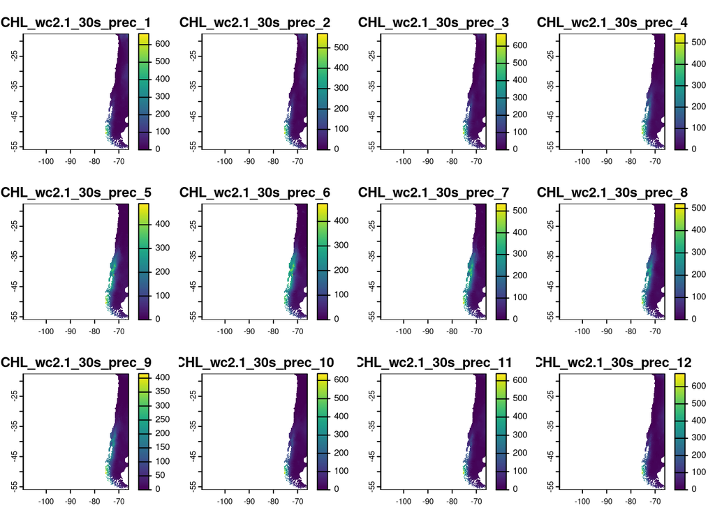

```r
par(mfrow = c(1,3))
plot(dem)
plot(prec)
```

**Código**

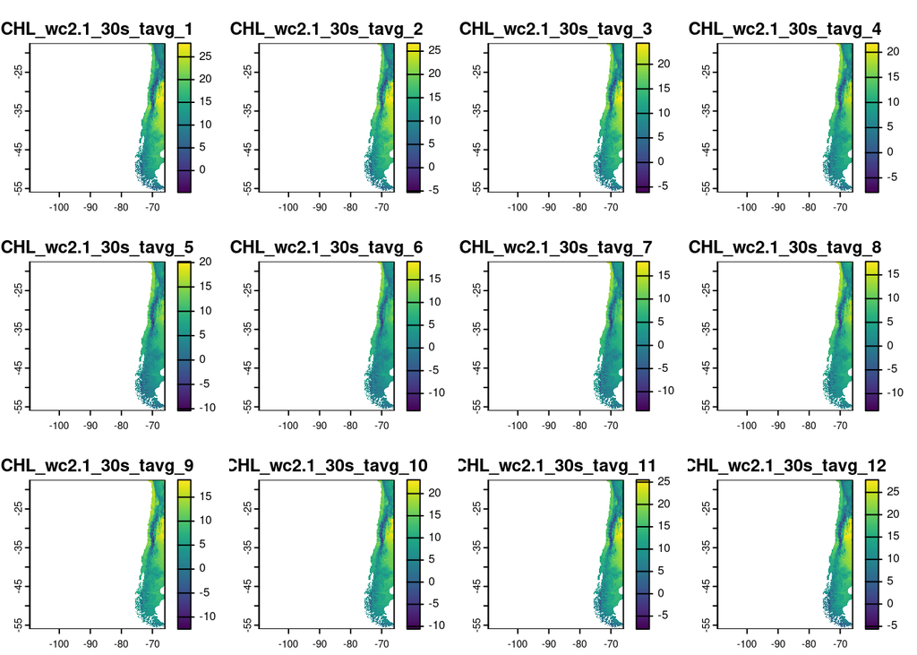

```r
plot(temp)
```

8.- Para las capas de temperatura y precipitación extraiga los meses de diciembre y guardelo en un objeto nuevo en R.

**Código**

```r
temp_dic <- subset(temp,12)
prec_dic <- subset(prec,12)
```

**Código**

```r
temp_dic_proj <- project(temp_dic,'EPSG:32719')
prec_dic_proj <- project(prec_dic,'EPSG:32719')

writeRaster(temp_dic_proj,'../data/capas_raster/temp_dic_proj.tif')
writeRaster(prec_dic_proj,'../data/capas_raster/prec_dic_proj.tif')
```